# The Effect of News and Tweets on the Price of Bitcoin

Ning Ding, Zaigham Khan, Chelsea Miao, Biyu Wang, and Anna Yass

4/19/2022

## R Set Up

### File names

```r
#1 Uncleaned_Merged_BitcoinNYTimesSnP.csv
#2 bitcoin.csv
#3 NYTimes.csv
#4 twitter.csv
#5 SnP.csv
#6 cleandata.csv
```

### Packages & Library

```r
#Set up R library with packages

#install.packages("tidytext")
#install.packages("lexicon")
#install.packages("textdata")
#install.packages("M3") #say no when asking for compilation
#install.packages("rgdal")
#install.packages("zoo")
#install.packages("textclean")
#install.packages("latticeExtra")


library(tidyr)
library(dplyr)
```

```r
library(ggplot2)
library(tidytext)
library(stringr)
library(lexicon)
library(textdata)
library(lubridate)
library(M3)
library(data.table)
library(zoo)
library(textclean)
library(tm)
library(h2o)
library(nnet)
library(randomForest)
library(rpart)
library(rpart.plot)
library(caret)
library(glmnet)
library(Matrix)
library(latticeExtra)
library(ggthemes)
library(gridExtra)
library(quantmod)
library(xts)
library(forecast)
library(fpp)
library(fpp2)
library(tseries)
library(lubridate)
library(urca)
library(vars)
library(mFilter)
library(tseries)
library(tidyverse)
library(zoo)
library(neuralnet)
```

### Raw Data Files

Preparing data for Time Series

```r
#Time Series
#Create a dataframe with all time intervals
ts <- seq(as.POSIXct("2022-01-01 05:00:00"), as.POSIXct("2022-02-22 12:00:00"),by = "hour")

df_ts <- data.frame(date=as.POSIXct(ts, format="%Y-%m-%d %H:%M:%S %z"))
names(df_ts)[names(df_ts) == 'date'] <- 'new_date'
```

Combining New York Times, Twitter, Bitcoin and S&P 500 data together

```r
bitcoin_data <- read.csv("bitcoin.csv")
df <- str_split_fixed(bitcoin_data$date, "T", 2)
bitcoin_data$date <- df[,1]
bitcoin_data$time <- df[,2]
bitcoin_data$time <- gsub(".000Z", "", bitcoin_data$time)
bitcoin_data$date <- ymd(bitcoin_data$date)
format <- "%Y-%m-%d %H:%M:%S"

bitcoin_data$new_date <-  as.POSIXct(paste(bitcoin_data$date, bitcoin_data$time), format=format)
```

```r
#Twitter
twitter_data <- read.csv("twitter.csv")
df <- str_split_fixed(twitter_data$Create_Date, " ", 2)

twitter_data$date <- df[,1]
twitter_data$time <- df[,2]
twitter_data$time <- gsub("+00:00", "", twitter_data$time)
twitter_data$time <- gsub('^|.$', '', twitter_data$time)
twitter_data$date <- ymd(twitter_data$date)

format <- "%Y-%m-%d %H:%M:%S"

twitter_data$Create_Date <- as.POSIXct(paste(twitter_data$date, twitter_data$time), format=format)

twitter_data$new_date <- ceiling_date(twitter_data$Create_Date, "hour")
twitter_data$text <- twitter_data$Tweet
twitter_data$source <- "Twitter"
```

```r
#New York Times News Data
news_data <- read.csv("NYTimes.csv",stringsAsFactors = T, na.strings=c("","NA","N/A"))

format <- "%m/%d/%Y %H:%M"

news_data$Create_Date <- as.POSIXct(news_data$created_time, format=format)
news_data$new_date <- ceiling_date(news_data$Create_Date, "hour")

news_data<- news_data %>%
  mutate(text = coalesce(snippet,headline))

news_data$source = news_data$news_desk
```

```r
#S&P500 data
SnP500_data <- read.csv("SnP.csv",stringsAsFactors = T, na.strings=c("","NA","N/A"))
SnP500_data$Date_copy <- mdy(SnP500_data$Date_copy)

format <- "%Y-%m-%d %H:%M"

SnP500_data$Create_Date <- as.POSIXct(paste(SnP500_data$Date_copy, SnP500_data$Time), format=format)
SnP500_data$new_date <- ceiling_date(SnP500_data$Create_Date, "hour")
```

```r
#Combining Bitcoin with Time Series
bitcoin_ts_df <- merge(bitcoin_data,df_ts,by="new_date",all.x=TRUE)

nrow(bitcoin_ts_df)
```

```
## [1] 1255
```

```r
nrow(df_ts)
```

```
## [1] 1256
```

```r
bitcoin_ts_df <- bitcoin_ts_df[!duplicated(bitcoin_ts_df),]
```

```r
#Combining Bitcoin with Twitter

bitcoin_twitter_df <- merge(bitcoin_ts_df,twitter_data,by="new_date",all.x=TRUE)
```

```r
#Dropping unnecessary columns
keep <- c("text","Create_Date","new_date","priceUsd","circulatingSupply","source")
bitcoin_twitter_df = bitcoin_twitter_df[,(names(bitcoin_twitter_df) %in% keep)]

#Remove duplicates in data
nrow(bitcoin_twitter_df)
```

```
## [1] 6046
```

```r
bitcoin_twitter_df <- bitcoin_twitter_df %>% distinct()
nrow(bitcoin_twitter_df)
```

```
## [1] 4427
```

```r
#Combining Bitcoin with News Data
bitcoin_news_df <- merge(bitcoin_data,news_data,by="new_date",all.x=TRUE)
keep <- c("text","Create_Date","new_date","priceUsd","circulatingSupply","source")
bitcoin_news_df = bitcoin_news_df[,(names(bitcoin_news_df) %in% keep)]

#Remove duplicates in data
nrow(bitcoin_news_df)
```

```
## [1] 2592
```

```r
bitcoin_news_df <- bitcoin_news_df %>% distinct()
nrow(bitcoin_news_df)
```

```
## [1] 2589
```

```r
#Union of both the dataframes combined_df and combined_df_2
twitter_news_bitcoin_df=union(bitcoin_twitter_df,bitcoin_news_df)

keep <- c("new_date","text","Create_Date","priceUsd","circulatingSupply","source")
twitter_news_bitcoin_df = twitter_news_bitcoin_df[,(names(twitter_news_bitcoin_df) %in% keep)]

write.csv(twitter_news_bitcoin_df,"Merged_Dataframe1.csv")

twitter_news_bitcoin_df$Create_Date_Copy <- twitter_news_bitcoin_df$Create_Date
twitter_news_bitcoin_df$Create_Date <- strptime(twitter_news_bitcoin_df$Create_Date,  format = "%Y-%m-%d %H:%M")
```

```r
#Joining the merged dataframe with SnP500_data

twitter_news_bitcoin_snp500_df= twitter_news_bitcoin_df %>% left_join(SnP500_data,by="Create_Date", all.x=TRUE)
names(twitter_news_bitcoin_snp500_df)[names(twitter_news_bitcoin_snp500_df) == 'new_date.x'] <- 'new_date'
names(twitter_news_bitcoin_snp500_df)[names(twitter_news_bitcoin_snp500_df) == 'new_date.y'] <- 'closest_snp500date'

#twitter_news_bitcoin_snp500_df %>% arrange(twitter_news_bitcoin_snp500_df$new_date)

twitter_news_bitcoin_snp500_df <- na.locf(twitter_news_bitcoin_snp500_df, fromLast = TRUE)

keep <- c("new_date","text","priceUsd","circulatingSupply","source","Close")
twitter_news_bitcoin_snp500_df = twitter_news_bitcoin_snp500_df[,(names(twitter_news_bitcoin_snp500_df) %in% keep)]
names(twitter_news_bitcoin_snp500_df)[names(twitter_news_bitcoin_snp500_df) == 'Close'] <- 'SnP500 Closing Price'

write.csv(twitter_news_bitcoin_snp500_df,"Merged_Raw_Dataframe.csv")
```

### Merged Data Files

```r
dta = read.csv("Merged_Raw_Dataframe.csv", header=TRUE, stringsAsFactor=T)
```

## Cleaning Part 1

### Date and Time Columns

Split up date column

```r
#Separating created_time into two separate columns
dta <- separate(data = dta, col = new_date, into  = c('date', 'time'), sep = ' ')

head(dta)
```

```
##   X       date     time priceUsd circulatingSupply
## 1 1 2022-01-01 05:00:00 46726.79          18916350
## 2 2 2022-01-01 06:00:00 47177.32          18916406
## 3 3 2022-01-01 07:00:00 47029.04          18916406
## 4 4 2022-01-01 08:00:00 47165.15          18916531
## 5 5 2022-01-01 09:00:00 47108.44          18916531
## 6 6 2022-01-01 10:00:00 47081.91          18916662
##                                                                                                                                                                                                                                 text
## 1                                                                                                                                                                                 Way to close out 2021 ðŸ\231Œ https://t.co/qWtDrIcwAo
## 2                                                                                                                                                                                 Way to close out 2021 ðŸ\231Œ https://t.co/qWtDrIcwAo
## 3                                                                                                                                                                                 Way to close out 2021 ðŸ\231Œ https://t.co/qWtDrIcwAo
## 4                                                                                                                                                                                 Way to close out 2021 ðŸ\231Œ https://t.co/qWtDrIcwAo
## 5                                                                                                                                                                                 Way to close out 2021 ðŸ\231Œ https://t.co/qWtDrIcwAo
## 6 #Bitcoin performance  [annual]:\n\n2009:  ðŸ”¼\n2010:   ðŸ”¼\n2011:    ðŸ”¼\n2012:   ðŸ”¼\n2013:   ðŸ”¼\n2014:   ðŸ”»\n2015:   ðŸ”¼\n2016:   ðŸ”¼\n2017:   ðŸ”¼\n2018:   ðŸ”»\n2019:   ðŸ”¼\n2020:  ðŸ”¼\n2021:   ðŸ”¼\n2022:  â\235”
##    source SnP500.Closing.Price
## 1 Twitter              4780.73
## 2 Twitter              4780.73
## 3 Twitter              4780.73
## 4 Twitter              4780.73
## 5 Twitter              4780.73
## 6 Twitter              4780.73
```

Converting date and time from character to factor

```r
dta$date <- as.factor(dta$date) #For date
dta$time <- as.factor(dta$time) #For time
```

Converting factor into POSIXt and then the date

```r
dta$date<-as.Date(dta$date,format="%Y-%m-%d") #Defining desire format of date

str(dta) #Examine variables and columns in dta, see how the date column is now "date"
```

```
## 'data.frame':    6887 obs. of  8 variables:
##  $ X                   : int  1 2 3 4 5 6 7 8 9 10 ...
##  $ date                : Date, format: "2022-01-01" "2022-01-01" ...
##  $ time                : Factor w/ 24 levels "00:00:00","01:00:00",..: 6 7 8 9 10 11 12 13 14 15 ...
##  $ priceUsd            : num  46727 47177 47029 47165 47108 ...
##  $ circulatingSupply   : int  18916350 18916406 18916406 18916531 18916531 18916662 18916662 18916750 18916750 18916818 ...
##  $ text                : Factor w/ 5876 levels "'Institutions are coming!'\n'What are they buying?'\n'Nothing... they are selling ______'. https://t.co/ixGJRicGS7",..: 5605 5605 5605 5605 5605 257 2772 2772 2772 4598 ...
##  $ source              : Factor w/ 4 levels "Bitcoin Article",..: 4 4 4 4 4 4 4 4 4 4 ...
##  $ SnP500.Closing.Price: num  4781 4781 4781 4781 4781 ...
```

### Converting Factor to Character Columns

```r
dta$text <- as.character(dta$text) #For text

dta$source <- as.character(dta$source) #For source
```

### Drop Unnecessary columns

```r
drop <- c("circulatingSupply")

dta = dta[,!(names(dta) %in% drop)]
```

### Renaming Columns

```r
names(dta)[1] <- 'ID'
names(dta)[4] <- 'BitcoinPrice'
names(dta)[7] <- 'SP500Price'

head(dta)
```

```
##   ID       date     time BitcoinPrice
## 1  1 2022-01-01 05:00:00     46726.79
## 2  2 2022-01-01 06:00:00     47177.32
## 3  3 2022-01-01 07:00:00     47029.04
## 4  4 2022-01-01 08:00:00     47165.15
## 5  5 2022-01-01 09:00:00     47108.44
## 6  6 2022-01-01 10:00:00     47081.91
##                                                                                                                                                                                                                                 text
## 1                                                                                                                                                                                 Way to close out 2021 ðŸ\231Œ https://t.co/qWtDrIcwAo
## 2                                                                                                                                                                                 Way to close out 2021 ðŸ\231Œ https://t.co/qWtDrIcwAo
## 3                                                                                                                                                                                 Way to close out 2021 ðŸ\231Œ https://t.co/qWtDrIcwAo
## 4                                                                                                                                                                                 Way to close out 2021 ðŸ\231Œ https://t.co/qWtDrIcwAo
## 5                                                                                                                                                                                 Way to close out 2021 ðŸ\231Œ https://t.co/qWtDrIcwAo
## 6 #Bitcoin performance  [annual]:\n\n2009:  ðŸ”¼\n2010:   ðŸ”¼\n2011:    ðŸ”¼\n2012:   ðŸ”¼\n2013:   ðŸ”¼\n2014:   ðŸ”»\n2015:   ðŸ”¼\n2016:   ðŸ”¼\n2017:   ðŸ”¼\n2018:   ðŸ”»\n2019:   ðŸ”¼\n2020:  ðŸ”¼\n2021:   ðŸ”¼\n2022:  â\235”
##    source SP500Price
## 1 Twitter    4780.73
## 2 Twitter    4780.73
## 3 Twitter    4780.73
## 4 Twitter    4780.73
## 5 Twitter    4780.73
## 6 Twitter    4780.73
```

### Reordering Columns

```r
dta <- dta[,c("ID", "date", "time", "text", "source","BitcoinPrice", "SP500Price")]

head(dta)
```

```
##   ID       date     time
## 1  1 2022-01-01 05:00:00
## 2  2 2022-01-01 06:00:00
## 3  3 2022-01-01 07:00:00
## 4  4 2022-01-01 08:00:00
## 5  5 2022-01-01 09:00:00
## 6  6 2022-01-01 10:00:00
##                                                                                                                                                                                                                                 text
## 1                                                                                                                                                                                 Way to close out 2021 ðŸ\231Œ https://t.co/qWtDrIcwAo
## 2                                                                                                                                                                                 Way to close out 2021 ðŸ\231Œ https://t.co/qWtDrIcwAo
## 3                                                                                                                                                                                 Way to close out 2021 ðŸ\231Œ https://t.co/qWtDrIcwAo
## 4                                                                                                                                                                                 Way to close out 2021 ðŸ\231Œ https://t.co/qWtDrIcwAo
## 5                                                                                                                                                                                 Way to close out 2021 ðŸ\231Œ https://t.co/qWtDrIcwAo
## 6 #Bitcoin performance  [annual]:\n\n2009:  ðŸ”¼\n2010:   ðŸ”¼\n2011:    ðŸ”¼\n2012:   ðŸ”¼\n2013:   ðŸ”¼\n2014:   ðŸ”»\n2015:   ðŸ”¼\n2016:   ðŸ”¼\n2017:   ðŸ”¼\n2018:   ðŸ”»\n2019:   ðŸ”¼\n2020:  ðŸ”¼\n2021:   ðŸ”¼\n2022:  â\235”
##    source BitcoinPrice SP500Price
## 1 Twitter     46726.79    4780.73
## 2 Twitter     47177.32    4780.73
## 3 Twitter     47029.04    4780.73
## 4 Twitter     47165.15    4780.73
## 5 Twitter     47108.44    4780.73
## 6 Twitter     47081.91    4780.73
```

## Cleaning Part 2

### Removing Upper Case

Converting everything to lower case letters

```r
dta$text <- tolower(dta$text)
```

### Cleaning Text Column

Removing unwanted items such as Emoji, links etc.

```r
#removing unwanted symbols/characters
dta$text <- replace_emoji(dta$text)
dta$text <- replace_emoticon(dta$text)
dta$text <- replace_non_ascii(dta$text)
dta$text <- replace_symbol(dta$text)
dta$text <- replace_word_elongation(dta$text)
dta$text <- replace_white(dta$text)
dta$text <- replace_contraction(dta$text)
dta$text <- replace_kern(dta$text)
dta$text <- replace_number(dta$text)
dta$text <- replace_ordinal(dta$text)

#removing hyperlinks
dta$text <- gsub(" ?/\\w+ ?", "", dta$text)
dta$text <- gsub(" ?http\\w+ ?", "", dta$text)
dta$text<-gsub("skeptical.co","",as.character(dta$text))
```

### Replacing abbreviations

```r
dta$text<-gsub("lol","laugh out loud",as.character(dta$text))
dta$text<-gsub("lmao","laughing my ass off",as.character(dta$text))
dta$text<-gsub("wut","what",as.character(dta$text))
dta$text<-gsub("wut","what",as.character(dta$text))
dta$text<-gsub("wtf","what the fuck",as.character(dta$text))
dta$text<-gsub("idk","i don't know",as.character(dta$text))
dta$text<-gsub("btc","bitcoin",as.character(dta$text))
dta$text<-gsub("gm","good morning",as.character(dta$text))
dta$text<-gsub("vid","video",as.character(dta$text))
dta$text<-gsub("payin'","paying",as.character(dta$text))
dta$text<-gsub("payin'","paying",as.character(dta$text))
dta$text<-gsub("g'day","good day",as.character(dta$text))
dta$text<-gsub("lfg","looking for group",as.character(dta$text))
dta$text<-gsub("hby","how about you",as.character(dta$text))
dta$text<-gsub("hodl","hold on for dear life",as.character(dta$text))
dta$text<-gsub("icymi","in case you missed it",as.character(dta$text))
```

### Remove Rows with NA Text

Removing rows of data with an empty cell in the text column. It means, this Twitter user or news article consists of unknown characters or symbols that cannot be identified. For example, removing someone that only tweeted an Emoji

```r
dta<-dta[!dta$text=="",]
```

### Removing Stop Words

```r
#Unnest

dta1 <- dta %>%
  unnest_paragraphs(word,text)%>%
  #select(word)%>%
  #mutate(word = gsub("/t.co", "'", word)) %>%
  anti_join(stop_words) %>%
  ungroup()
head(dta1)
```

```
##   ID       date     time  source BitcoinPrice SP500Price
## 1  1 2022-01-01 05:00:00 Twitter     46726.79    4780.73
## 2  2 2022-01-01 06:00:00 Twitter     47177.32    4780.73
## 3  3 2022-01-01 07:00:00 Twitter     47029.04    4780.73
## 4  4 2022-01-01 08:00:00 Twitter     47165.15    4780.73
## 5  5 2022-01-01 09:00:00 Twitter     47108.44    4780.73
## 6  6 2022-01-01 10:00:00 Twitter     47081.91    4780.73
##                                                                                                                                                      word
## 1                                                                                                                way to close out two thousand twenty-one
## 2                                                                                                                way to close out two thousand twenty-one
## 3                                                                                                                way to close out two thousand twenty-one
## 4                                                                                                                way to close out two thousand twenty-one
## 5                                                                                                                way to close out two thousand twenty-one
## 6 number bitcoin performance [annual]: 2009: 12010: 12011: 12012: 12013: 12014: 2015: 12016: 12017: 12018: 2019: 12020: 12021: 12022: white question mark
```

```r
#Vector for stop words
vec<-tm::stopwords("english")

#Filter
dta1<-dta1[!(dta1$word %in% vec),]
#Re aggregate by id
#dta1 <- dta1 %>% group_by(ID) %>% summarise(text=paste0(word,collapse = ' '))

head(dta1)
```

```
##   ID       date     time  source BitcoinPrice SP500Price
## 1  1 2022-01-01 05:00:00 Twitter     46726.79    4780.73
## 2  2 2022-01-01 06:00:00 Twitter     47177.32    4780.73
## 3  3 2022-01-01 07:00:00 Twitter     47029.04    4780.73
## 4  4 2022-01-01 08:00:00 Twitter     47165.15    4780.73
## 5  5 2022-01-01 09:00:00 Twitter     47108.44    4780.73
## 6  6 2022-01-01 10:00:00 Twitter     47081.91    4780.73
##                                                                                                                                                      word
## 1                                                                                                                way to close out two thousand twenty-one
## 2                                                                                                                way to close out two thousand twenty-one
## 3                                                                                                                way to close out two thousand twenty-one
## 4                                                                                                                way to close out two thousand twenty-one
## 5                                                                                                                way to close out two thousand twenty-one
## 6 number bitcoin performance [annual]: 2009: 12010: 12011: 12012: 12013: 12014: 2015: 12016: 12017: 12018: 2019: 12020: 12021: 12022: white question mark
```

## News/Twitter Data Exploration

### Looking at words

Columns

```r
dta_with_words <- dta1 %>%
  unnest_tokens(word, word) %>%
  anti_join(stop_words, by= c("word" = "word"))

head(dta_with_words)
```

```
##   ID       date     time  source BitcoinPrice SP500Price     word
## 1  1 2022-01-01 05:00:00 Twitter     46726.79    4780.73    close
## 2  1 2022-01-01 05:00:00 Twitter     46726.79    4780.73 thousand
## 3  1 2022-01-01 05:00:00 Twitter     46726.79    4780.73   twenty
## 4  2 2022-01-01 06:00:00 Twitter     47177.32    4780.73    close
## 5  2 2022-01-01 06:00:00 Twitter     47177.32    4780.73 thousand
## 6  2 2022-01-01 06:00:00 Twitter     47177.32    4780.73   twenty
```

```r
nrc_lexicon <- get_sentiments("nrc")

#now the job
dta_with_words1 <- dta_with_words %>%
             unnest_tokens(word, word) %>%  # unnest the words
             left_join(nrc_lexicon) %>%     # join with the lexicon to have sentiments
             left_join(dta_with_words)      # join with your data to have titles
table_sentiment <- table(dta_with_words1$ID, dta_with_words1$sentiment)

df_sentiment <- as.data.frame.matrix(table_sentiment)

#create ID
df_sentiment<- tibble::rowid_to_column(df_sentiment, "ID")

head(df_sentiment)
```

```
##   ID anger anticipation disgust fear joy negative positive sadness surprise
## 1  1     0            0       0    0   0        0        0       0        0
## 2  2     0            0       0    0   0        0        0       0        0
## 3  3     0            0       0    0   0        0        0       0        0
## 4  4     0            0       0    0   0        0        0       0        0
## 5  5     0            0       0    0   0        0        0       0        0
## 6  6     0            0       0    0   0        0        1       0        0
##   trust
## 1     0
## 2     0
## 3     0
## 4     0
## 5     0
## 6     0
```

```r
dta55 <- merge(dta_with_words1, df_sentiment, by="ID")
```

### News dataframe

Break up into just news data for further data exploration

```r
dta_news <- dta %>%
  filter(str_detect(source, 'Business|Financial|Bitcoin News'))
```

### Twitter dataframe

Break up into just twitter data for further data exploration

```r
dta_twitter <- dta %>%
  filter(str_detect(source, 'Twitter'))
```

### Mean words

In both and news and Twitter data frame

```r
mean(sapply(strsplit(as.character(dta$text), "[[:space:]]+"), length)) #average number of words in news headline and tweets
```

```
## [1] 20.95234
```

```r
mean(sapply(strsplit(as.character(dta_news$text), "[[:space:]]+"), length)) #for news
```

```
## [1] 21.56791
```

```r
mean(sapply(strsplit(as.character(dta_twitter$text), "[[:space:]]+"), length)) #for twitter
```

```
## [1] 20.62514
```

### Proportion of positive/negative words in news articles & tweets

```r
#for news - shows there are 45% positive and 55% negative
dta_news %>%
  unnest_tokens(output=word,input=text)%>%
  inner_join(get_sentiments('bing'))%>%
  group_by(sentiment)%>%
  summarize(n = n())%>%
  mutate(proportion = n/sum(n))%>%
  ungroup()
```

```
## # A tibble: 2 x 3
##   sentiment     n proportion
##   <chr>     <int>      <dbl>
## 1 negative   1729      0.551
## 2 positive   1410      0.449
```

```r
#for tweets - shows there are 60% positive and 40% negative - for later to see if just filter for bitcoin news

dta_twitter %>%
  unnest_tokens(output=word,input=text)%>%
  inner_join(get_sentiments('bing'))%>%
  group_by(sentiment)%>%
  summarize(n = n())%>%
  mutate(proportion = n/sum(n))%>%
  ungroup()
```

```
## # A tibble: 2 x 3
##   sentiment     n proportion
##   <chr>     <int>      <dbl>
## 1 negative   1763      0.412
## 2 positive   2517      0.588
```

## NRC Sentiment Polarity Lexicon sentiment for news

```r
head(hash_sentiment_nrc)
```

```
##              x  y
## 1:     abandon -1
## 2:   abandoned -1
## 3: abandonment -1
## 4:        abba  1
## 5:   abduction -1
## 6:    aberrant -1
```

```r
hash_sentiment_nrc %>%
  group_by(y)%>%
  summarize(count= n())%>%
  ungroup()
```

```
## # A tibble: 2 x 2
##       y count
##   <int> <int>
## 1    -1  3241
## 2     1  2227
```

```r
dta_news %>%
  unnest_tokens(output = word, input = text)%>%
  inner_join(y = hash_sentiment_nrc,by = c('word'='x'))%>%
  group_by(y)%>%
  summarize(count = n())%>%
  ungroup()
```

```
## # A tibble: 2 x 2
##       y count
##   <int> <int>
## 1    -1  2033
## 2     1  2784
```

### Downloading Lexicon

```r
nrc = read.table(
                 file ='https://raw.githubusercontent.com/pseudorational/data/master/nrc_lexicon.txt',
                 header =F,
                 col.names =c('word','sentiment','num'),
                 sep ='\t',
                 stringsAsFactors =F)
nrc = nrc[nrc$num!=0,]
nrc$num = NULL
```

### List of Lexicon emotions

```r
nrc%>%
  group_by(sentiment)%>%
  count()%>%
  ungroup()
```

```
## # A tibble: 10 x 2
##    sentiment        n
##    <chr>        <int>
##  1 anger         1247
##  2 anticipation   839
##  3 disgust       1058
##  4 fear          1476
##  5 joy            689
##  6 negative      3324
##  7 positive      2312
##  8 sadness       1191
##  9 surprise       534
## 10 trust         1231
```

### Top emotions for news & twitter

```r
dta_news%>%
  unnest_tokens(output = word, input = text)%>%
  inner_join(nrc)%>%
  group_by(sentiment)%>%
  count()%>%
  arrange(desc(n))%>%
  ungroup()
```

```
## # A tibble: 10 x 2
##    sentiment        n
##    <chr>        <int>
##  1 positive      2920
##  2 negative      2150
##  3 trust         1910
##  4 fear          1406
##  5 anticipation  1346
##  6 anger          980
##  7 sadness        972
##  8 joy            885
##  9 surprise       659
## 10 disgust        432
```

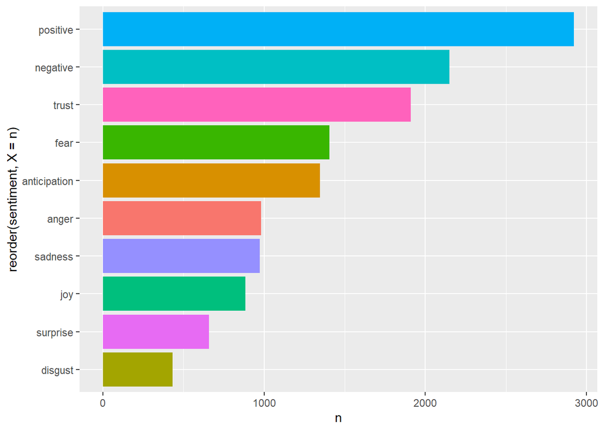

```r
#visualization

dta_news%>%
  unnest_tokens(output = word, input = text)%>%
  inner_join(nrc)%>%
  group_by(sentiment)%>%
  count()%>%
  ungroup()%>%
  ggplot(aes(x=reorder(sentiment,X = n),y=n,fill=sentiment))+
         geom_col()+guides(fill=F)+coord_flip()
```

### Top Emotions for Twitter

```r
dta_twitter%>%
  unnest_tokens(output = word, input = text)%>%
  inner_join(nrc)%>%
  group_by(sentiment)%>%
  count()%>%
  arrange(desc(n))%>%
  ungroup()
```

```
## # A tibble: 10 x 2
##    sentiment        n
##    <chr>        <int>
##  1 positive      4406
##  2 trust         2987
##  3 anticipation  2323
##  4 negative      1956
##  5 joy           1638
##  6 fear          1193
##  7 surprise       897
##  8 anger          868
##  9 sadness        795
## 10 disgust        336
```

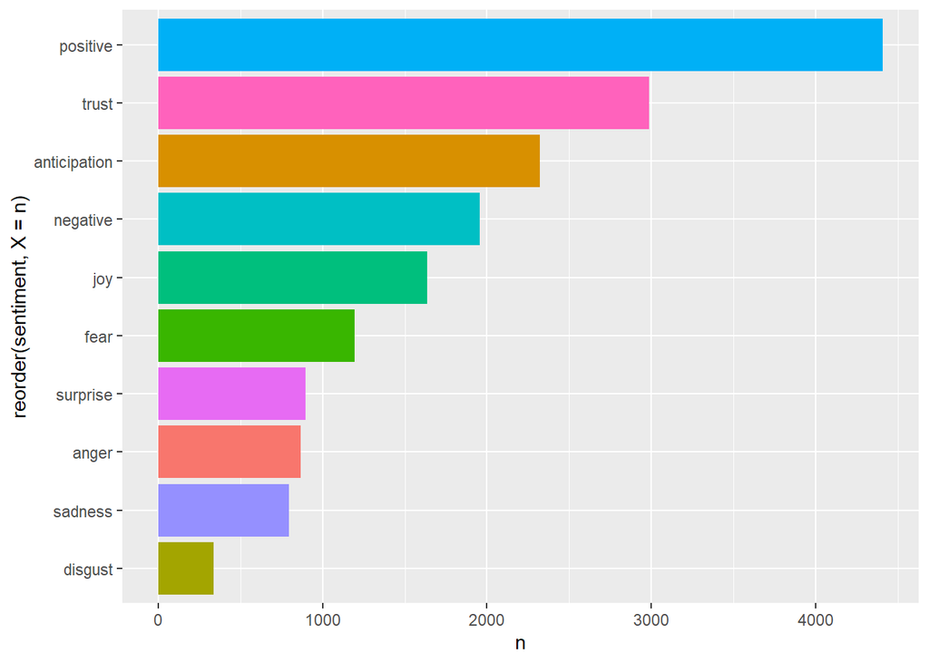

```r
#check to see if this makes sense

dta_twitter%>%
  unnest_tokens(output = word, input = text)%>%
  inner_join(nrc)%>%
  group_by(sentiment)%>%
  count()%>%
  ungroup()%>%
  ggplot(aes(x=reorder(sentiment,X = n),y=n,fill=sentiment))+
         geom_col()+guides(fill=F)+coord_flip()
```

## Bitcoin S&P500 Data Exploration

### Bitcoin and S&P500 Prices

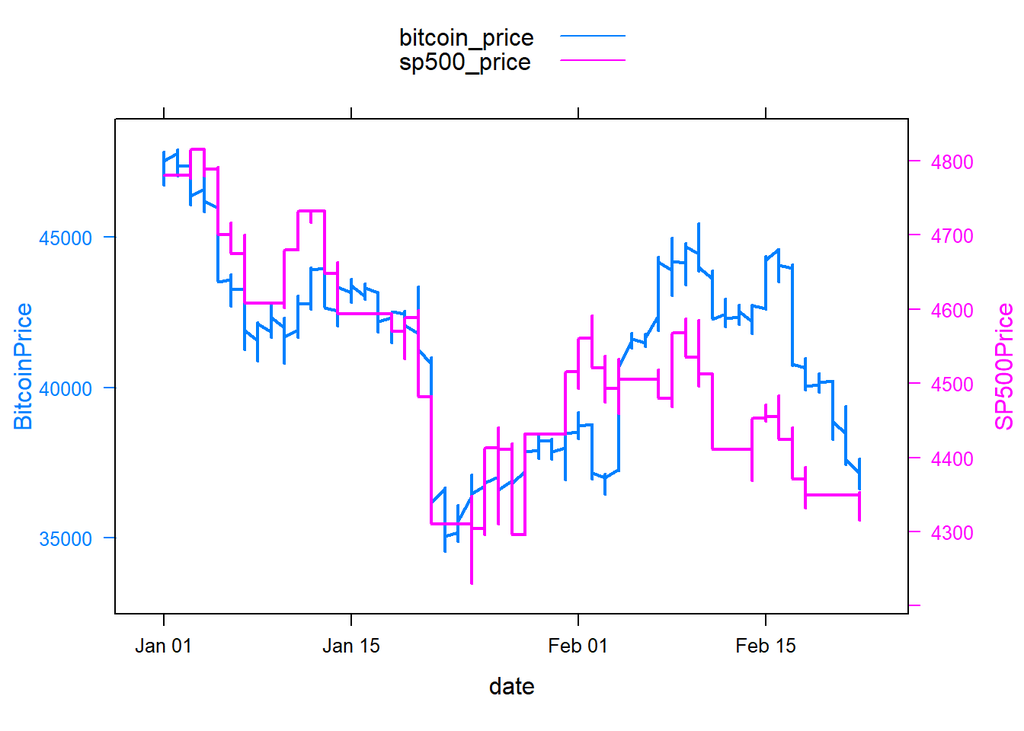

```r
twitterfilter <- dta %>%
  filter(source == "Twitter")

# --> construct separate plots for each series
bitcoin_price <- xyplot(BitcoinPrice ~ date, twitterfilter, type = "l" , lwd=2)
sp500_price <- xyplot(SP500Price ~ date, twitterfilter, type = "l", lwd=2)

# --> Make the plot with second y axis:
doubleYScale(bitcoin_price, sp500_price,text = c("bitcoin_price", "sp500_price"), add.ylab2 = TRUE)
```

### Correlation between prices

```r
cor(dta$BitcoinPrice, dta$SP500Price)
```

```
## [1] 0.6210255
```

## Cleaning Part 3

### Create new columns for model

```r
dta5 <- dcast(setDT(dta1), ID + date + time + source + BitcoinPrice + SP500Price + word ~ source, value.var = 'source', fill = "")

head(dta5)
```

```
##    ID       date     time  source BitcoinPrice SP500Price
## 1:  1 2022-01-01 05:00:00 Twitter     46726.79    4780.73
## 2:  2 2022-01-01 06:00:00 Twitter     47177.32    4780.73
## 3:  3 2022-01-01 07:00:00 Twitter     47029.04    4780.73
## 4:  4 2022-01-01 08:00:00 Twitter     47165.15    4780.73
## 5:  5 2022-01-01 09:00:00 Twitter     47108.44    4780.73
## 6:  6 2022-01-01 10:00:00 Twitter     47081.91    4780.73
##                                                                                                                                                       word
## 1:                                                                                                                way to close out two thousand twenty-one
## 2:                                                                                                                way to close out two thousand twenty-one
## 3:                                                                                                                way to close out two thousand twenty-one
## 4:                                                                                                                way to close out two thousand twenty-one
## 5:                                                                                                                way to close out two thousand twenty-one
## 6: number bitcoin performance [annual]: 2009: 12010: 12011: 12012: 12013: 12014: 2015: 12016: 12017: 12018: 2019: 12020: 12021: 12022: white question mark
##    Bitcoin Article Business Financial  Twitter
## 1:                                     Twitter
## 2:                                     Twitter
## 3:                                     Twitter
## 4:                                     Twitter
## 5:                                     Twitter
## 6:                                     Twitter
```

### Replace column names with 1’s

```r
dta5$Twitter_1 <- gsub("Twitter", "1", dta5$Twitter)


dta5$Bitcoin_Article_1 <- gsub("Bitcoin_Article", "1", dta5$Bitcoin_Article)


dta5$Business_1<- gsub("Business", "1", dta5$Business)


dta5$Financial_1 <- gsub("Financial", "1", dta5$Financial)


#drop other columns
dta5 <- subset(dta5, select = -c(8:11))
```

### Replace all NA and empty columns to 0

```r
dta6<- dta5 %>%
   mutate(across(c("Bitcoin_Article_1","Twitter_1", "Business_1", "Financial_1"), ~ifelse(.=="", 0, as.character(.))))

dta6[is.na(dta6)] <- 0
```

### Final New Columns

```r
dta_final <- merge(df_sentiment, dta6, by="ID")

head(dta_final)
```

```
##   ID anger anticipation disgust fear joy negative positive sadness surprise
## 1  1     0            0       0    0   0        0        0       0        0
## 2  2     0            0       0    0   0        0        0       0        0
## 3  3     0            0       0    0   0        0        0       0        0
## 4  4     0            0       0    0   0        0        0       0        0
## 5  5     0            0       0    0   0        0        0       0        0
## 6  6     0            0       0    0   0        0        1       0        0
##   trust       date     time  source BitcoinPrice SP500Price
## 1     0 2022-01-01 05:00:00 Twitter     46726.79    4780.73
## 2     0 2022-01-01 06:00:00 Twitter     47177.32    4780.73
## 3     0 2022-01-01 07:00:00 Twitter     47029.04    4780.73
## 4     0 2022-01-01 08:00:00 Twitter     47165.15    4780.73
## 5     0 2022-01-01 09:00:00 Twitter     47108.44    4780.73
## 6     0 2022-01-01 10:00:00 Twitter     47081.91    4780.73
##                                                                                                                                                      word
## 1                                                                                                                way to close out two thousand twenty-one
## 2                                                                                                                way to close out two thousand twenty-one
## 3                                                                                                                way to close out two thousand twenty-one
## 4                                                                                                                way to close out two thousand twenty-one
## 5                                                                                                                way to close out two thousand twenty-one
## 6 number bitcoin performance [annual]: 2009: 12010: 12011: 12012: 12013: 12014: 2015: 12016: 12017: 12018: 2019: 12020: 12021: 12022: white question mark
##   Twitter_1 Bitcoin_Article_1 Business_1 Financial_1
## 1         1                 0          0           0
## 2         1                 0          0           0
## 3         1                 0          0           0
## 4         1                 0          0           0
## 5         1                 0          0           0
## 6         1                 0          0           0
```

```r
dta_new <- dta_final %>%
  dplyr::select(anger, anticipation, disgust, fear, joy, negative, positive, sadness, surprise,
         trust) %>%
  mutate_if(is.integer, ~ 1 * (. > 0)) #if any number is greater than 1, replace with a 1


#create ID column
dta_new1<- tibble::rowid_to_column(dta_new, "ID")


dta_final1 <- merge(dta_new1, dta6, by="ID", all.dta6 = TRUE)

head(dta_final1)
```

```
##   ID anger anticipation disgust fear joy negative positive sadness surprise
## 1  1     0            0       0    0   0        0        0       0        0
## 2  2     0            0       0    0   0        0        0       0        0
## 3  3     0            0       0    0   0        0        0       0        0
## 4  4     0            0       0    0   0        0        0       0        0
## 5  5     0            0       0    0   0        0        0       0        0
## 6  6     0            0       0    0   0        0        1       0        0
##   trust       date     time  source BitcoinPrice SP500Price
## 1     0 2022-01-01 05:00:00 Twitter     46726.79    4780.73
## 2     0 2022-01-01 06:00:00 Twitter     47177.32    4780.73
## 3     0 2022-01-01 07:00:00 Twitter     47029.04    4780.73
## 4     0 2022-01-01 08:00:00 Twitter     47165.15    4780.73
## 5     0 2022-01-01 09:00:00 Twitter     47108.44    4780.73
## 6     0 2022-01-01 10:00:00 Twitter     47081.91    4780.73
##                                                                                                                                                      word
## 1                                                                                                                way to close out two thousand twenty-one
## 2                                                                                                                way to close out two thousand twenty-one
## 3                                                                                                                way to close out two thousand twenty-one
## 4                                                                                                                way to close out two thousand twenty-one
## 5                                                                                                                way to close out two thousand twenty-one
## 6 number bitcoin performance [annual]: 2009: 12010: 12011: 12012: 12013: 12014: 2015: 12016: 12017: 12018: 2019: 12020: 12021: 12022: white question mark
##   Twitter_1 Bitcoin_Article_1 Business_1 Financial_1
## 1         1                 0          0           0
## 2         1                 0          0           0
## 3         1                 0          0           0
## 4         1                 0          0           0
## 5         1                 0          0           0
## 6         1                 0          0           0
```

```r
dta_final1 <- dta_final1[,c("ID", "date", "time", "word", "source","BitcoinPrice", "SP500Price", "Bitcoin_Article_1","Twitter_1", "Business_1", "Financial_1","anger", "anticipation", "disgust", "fear", "joy", "negative", "positive", "sadness", "surprise", "trust")]

drop <- c("source") #drop the source column since it is now separated columns
dta_final1_model = dta_final1[,!(names(dta_final1) %in% drop)]

head(dta_final1_model)
```

```
##   ID       date     time
## 1  1 2022-01-01 05:00:00
## 2  2 2022-01-01 06:00:00
## 3  3 2022-01-01 07:00:00
## 4  4 2022-01-01 08:00:00
## 5  5 2022-01-01 09:00:00
## 6  6 2022-01-01 10:00:00
##                                                                                                                                                      word
## 1                                                                                                                way to close out two thousand twenty-one
## 2                                                                                                                way to close out two thousand twenty-one
## 3                                                                                                                way to close out two thousand twenty-one
## 4                                                                                                                way to close out two thousand twenty-one
## 5                                                                                                                way to close out two thousand twenty-one
## 6 number bitcoin performance [annual]: 2009: 12010: 12011: 12012: 12013: 12014: 2015: 12016: 12017: 12018: 2019: 12020: 12021: 12022: white question mark
##   BitcoinPrice SP500Price Bitcoin_Article_1 Twitter_1 Business_1 Financial_1
## 1     46726.79    4780.73                 0         1          0           0
## 2     47177.32    4780.73                 0         1          0           0
## 3     47029.04    4780.73                 0         1          0           0
## 4     47165.15    4780.73                 0         1          0           0
## 5     47108.44    4780.73                 0         1          0           0
## 6     47081.91    4780.73                 0         1          0           0
##   anger anticipation disgust fear joy negative positive sadness surprise trust
## 1     0            0       0    0   0        0        0       0        0     0
## 2     0            0       0    0   0        0        0       0        0     0
## 3     0            0       0    0   0        0        0       0        0     0
## 4     0            0       0    0   0        0        0       0        0     0
## 5     0            0       0    0   0        0        0       0        0     0
## 6     0            0       0    0   0        0        1       0        0     0
```

### Updating Date and Time

Prep the data for Time Series model

```r
final_data <- read.csv("cleandata_final.csv")

final_data$date <- ymd(final_data$date) #please change this according to personal R setting, might need to change to "ymd"

final_data$newdate <- as.POSIXct(paste(final_data$date, final_data$time), format="%Y-%m-%d %H:%M:%S")

head(final_data)
```

```
##   X.5 X.4 X.3 X.2 X.1 X ID       date     time
## 1   1   1   1   1   1 1  1 2022-01-01 05:00:00
## 2   2   2   2   2   2 2  2 2022-01-01 06:00:00
## 3   3   3   3   3   3 3  3 2022-01-01 07:00:00
## 4   4   4   4   4   4 4  4 2022-01-01 08:00:00
## 5   5   5   5   5   5 5  5 2022-01-01 09:00:00
## 6   6   6   6   6   6 6  6 2022-01-01 10:00:00
##                                                                                                                                                      word
## 1                                                                                                                way to close out two thousand twenty-one
## 2                                                                                                                way to close out two thousand twenty-one
## 3                                                                                                                way to close out two thousand twenty-one
## 4                                                                                                                way to close out two thousand twenty-one
## 5                                                                                                                way to close out two thousand twenty-one
## 6 number bitcoin performance [annual]: 2009: 12010: 12011: 12012: 12013: 12014: 2015: 12016: 12017: 12018: 2019: 12020: 12021: 12022: white question mark
##   BitcoinPrice SP500Price Bitcoin_Article_1 Twitter_1 Business_1 Financial_1
```

[output cut: 20 more lines]

```r
cleandata_final <- write.csv(final_data,"cleandata_final.csv") #exporting final cleaned dataset
```

### Creating new date and time columns

```r
final_data_hourly <- final_data %>%
  dplyr::mutate(new_date=newdate) %>%
  dplyr::group_by(new_date) %>%
  dplyr::summarise(BitcoinPrice = mean(BitcoinPrice))
```

```r
for (col in colnames(final_data)) {
  if ((col!= "BitcoinPrice") && (col!="newdate")){
    print(col)
    final_data_hourly[col] <- final_data %>%
      dplyr::select(col, newdate)%>%
      dplyr::group_by(newdate) %>%
      dplyr::summarise(col=mean(get(col))) %>% dplyr::select(col)
  }
}
```

```
## [1] "X.5"
```

```
## Note: Using an external vector in selections is ambiguous.
## i Use `all_of(col)` instead of `col` to silence this message.
## i See <https://tidyselect.r-lib.org/reference/faq-external-vector.html>.
```

```
## [1] "X.4"
## [1] "X.3"
## [1] "X.2"
## [1] "X.1"
## [1] "X"
## [1] "ID"
## [1] "date"
## [1] "time"
```

[output not shown]

[output cut: 3691 more lines]

[output not shown]

```
## [1] "word"
```

[output not shown]

[output cut: 3691 more lines]

[output not shown]

```
## [1] "SP500Price"
## [1] "Bitcoin_Article_1"
## [1] "Twitter_1"
## [1] "Business_1"
## [1] "Financial_1"
## [1] "anger"
## [1] "anticipation"
## [1] "disgust"
## [1] "fear"
## [1] "joy"
## [1] "negative"
## [1] "positive"
## [1] "sadness"
## [1] "surprise"
## [1] "trust"
```

### Viewing Data

```r
head(final_data_hourly)
```

```
## # A tibble: 6 x 27
##   new_date            BitcoinPrice   X.5   X.4   X.3   X.2   X.1     X    ID
##   <dttm>                     <dbl> <dbl> <dbl> <dbl> <dbl> <dbl> <dbl> <dbl>
## 1 2022-01-01 05:00:00       46727.    1     1     1     1     1     1     1
## 2 2022-01-01 06:00:00       47177. 2181  2181  2181  2181  2181  2181  2215
## 3 2022-01-01 07:00:00       47029.    3     3     3     3     3     3     3
## 4 2022-01-01 08:00:00       47165.    4     4     4     4     4     4     4
## 5 2022-01-01 09:00:00       47108. 2183  2183  2183  2183  2183  2183  2217
## 6 2022-01-01 10:00:00       47082. 3881. 3881. 3881. 3881. 3881. 3881. 3942.
## # ... with 18 more variables: date <date>, time <dbl>, word <dbl>,
## #   SP500Price <dbl>, Bitcoin_Article_1 <dbl>, Twitter_1 <dbl>,
## #   Business_1 <dbl>, Financial_1 <dbl>, anger <dbl>, anticipation <dbl>,
## #   disgust <dbl>, fear <dbl>, joy <dbl>, negative <dbl>, positive <dbl>,
## #   sadness <dbl>, surprise <dbl>, trust <dbl>
```

### Setting Bitcoin and S&P 500 Price TIme

```r
#Setting bitcoin price time
bitcoin_price_ts <- zoo(
  x         = final_data_hourly[["BitcoinPrice"]],
  order.by  = final_data_hourly[["new_date"]],
  frequency = 24
)

#Setting S&P 500 price time
SP500_ts <- zoo(
  x         = final_data_hourly[["SP500Price"]],
  order.by  = final_data_hourly[["new_date"]],
  frequency = 24
)

#Setting news data with time
Bitcoin_Article_ts <- zoo(
  x         = final_data_hourly[["Bitcoin_Article_1"]],
  order.by  = final_data_hourly[["new_date"]],
  frequency = 24
)
Business_ts <- zoo(
  x         = final_data_hourly[["Business_1"]],
  order.by  = final_data_hourly[["new_date"]],
  frequency = 24
)

Financial_ts <- zoo(
  x         = final_data_hourly[["Financial_1"]],
  order.by  = final_data_hourly[["new_date"]],
  frequency = 24
)

anger_ts <- zoo(
  x         = final_data_hourly[["anger"]],
  order.by  = final_data_hourly[["new_date"]],
  frequency = 24
)

anticipation_ts <- zoo(
  x         = final_data_hourly[["anticipation"]],
  order.by  = final_data_hourly[["new_date"]],
  frequency = 24
)

disgust_ts <- zoo(
  x         = final_data_hourly[["disgust"]],
  order.by  = final_data_hourly[["new_date"]],
  frequency = 24
)

fear_ts <- zoo(
  x         = final_data_hourly[["fear"]],
  order.by  = final_data_hourly[["new_date"]],
  frequency = 24
)

joy_ts <- zoo(
  x         = final_data_hourly[["joy"]],
  order.by  = final_data_hourly[["new_date"]],
  frequency = 24
)

negative_ts <- zoo(
  x         = final_data_hourly[["negative"]],
  order.by  = final_data_hourly[["new_date"]],
  frequency = 24
)

positive_ts <- zoo(
  x         = final_data_hourly[["positive"]],
  order.by  = final_data_hourly[["new_date"]],
  frequency = 24
)

sadness_ts <- zoo(
  x         = final_data_hourly[["sadness"]],
  order.by  = final_data_hourly[["new_date"]],
  frequency = 24
)

surprise_ts <- zoo(
  x         = final_data_hourly[["surprise"]],
  order.by  = final_data_hourly[["new_date"]],
  frequency = 24
)

trust_ts <- zoo(
  x         = final_data_hourly[["trust"]],
  order.by  = final_data_hourly[["new_date"]],
  frequency = 24
)
```

### Examining the data

```r
start(bitcoin_price_ts)
```

```
## [1] "2022-01-01 05:00:00 EST"
```

```r
end(bitcoin_price_ts)
```

```
## [1] "2022-02-22 12:00:00 EST"
```

```r
length(bitcoin_price_ts)
```

```
## [1] 1249
```

```r
class(bitcoin_price_ts)
```

```
## [1] "zooreg" "zoo"
```

## Predictive Modeling

### Research Question 1

Do the sentiments of tweets and news influence the price of Bitcoin?

#### Split Data

Split the data into train vs test

```r
set.seed(100)

split = sample(1:nrow(dta_final1_model),size = 0.7*nrow(dta_final1_model))
train = dta_final1_model[split,]
test = dta_final1_model[-split,]
```

```r
names(dta_final1_model) #check the names of columns
```

```
##  [1] "ID"                "date"              "time"
##  [4] "word"              "BitcoinPrice"      "SP500Price"
##  [7] "Bitcoin_Article_1" "Twitter_1"         "Business_1"
## [10] "Financial_1"       "anger"             "anticipation"
## [13] "disgust"           "fear"              "joy"
## [16] "negative"          "positive"          "sadness"
## [19] "surprise"          "trust"
```

#### Linear Regression Model 1

Predicting Bitcoin price (y) with the following independent variables: anger, anticipation, digust, fear, joy, negative, positive, sadness, surprise, trust

```r
reg1 = lm(BitcoinPrice ~ anger + anticipation + disgust + fear + joy + negative
            + positive + sadness + surprise + trust, train)

summary(reg1)
```

```
##
## Call:
## lm(formula = BitcoinPrice ~ anger + anticipation + disgust +
##     fear + joy + negative + positive + sadness + surprise + trust,
##     data = train)
##
## Residuals:
##     Min      1Q  Median      3Q     Max
## -7738.7 -2838.9   777.2  2283.9  7018.5
##
## Coefficients:
##              Estimate Std. Error t value Pr(>|t|)
## (Intercept)  41088.73      76.33 538.325  < 2e-16 ***
## anger          159.60     136.06   1.173 0.240859
## anticipation  -157.51     111.64  -1.411 0.158364
## disgust         27.16     166.88   0.163 0.870741
## fear           218.25     129.34   1.687 0.091602 .
## joy            480.00     135.53   3.542 0.000402 ***
## negative      -235.40     125.27  -1.879 0.060290 .
## positive       -27.61     112.75  -0.245 0.806579
## sadness        -61.55     140.67  -0.438 0.661722
## surprise        57.08     136.24   0.419 0.675284
## trust         -165.94     110.69  -1.499 0.133916
## ---
## Signif. codes:  0 '***' 0.001 '**' 0.01 '*' 0.05 '.' 0.1 ' ' 1
##
## Residual standard error: 3026 on 4651 degrees of freedom
## Multiple R-squared:  0.004921,   Adjusted R-squared:  0.002782
## F-statistic:   2.3 on 10 and 4651 DF,  p-value: 0.01087
```

```r
# Finding the RMSE of the first Linear Regression model

pred_reg1 = predict(reg1, newdata=test)
rmse_reg1 = sqrt(mean((pred_reg1-test$BitcoinPrice)^2));
rmse_reg1
```

```
## [1] 2970.252
```

#### Random Forest

Keep in mind, this is using the same test, train split

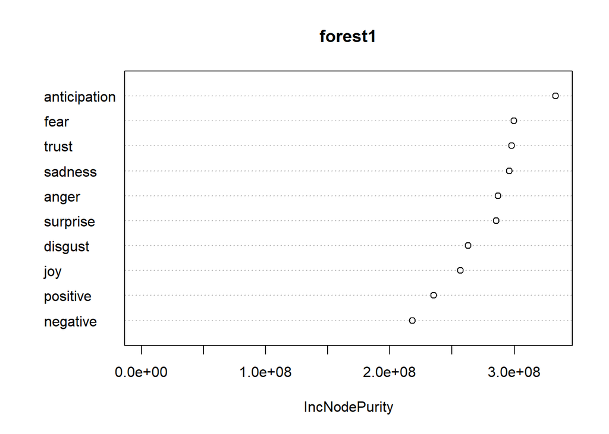

```r
set.seed(100)

forest1 = randomForest(BitcoinPrice~ anger + anticipation + disgust + fear + joy + negative
            + positive + sadness + surprise + trust,
            train,
            ntree=1000)

# Finding the importance of variables
varImpPlot(forest1)
```

```r
importance(forest1)
```

```
##              IncNodePurity
## anger            287056475
## anticipation     333418781
## disgust          263074267
## fear             299735517
## joy              256710437
## negative         218217811
## positive         235315864
## sadness          296219351
## surprise         285421002
## trust            298100040
```

```r
# Finding the RMSE of the randomForest model
pred_forest1 = predict(forest1, newdata=test)
rmse_forest1 = sqrt(mean((pred_forest1-test$BitcoinPrice)^2))
rmse_forest1
```

```
## [1] 2962.157
```

#### Basic Neural Networks

```r
set.seed(100)
model1 = nnet(BitcoinPrice~ anger + anticipation + disgust
            + fear + joy + negative + positive + sadness + surprise + trust,
             data = train,
             size=5,
             decay=0.1,
             MaxNWts=10000,
             maxit=1000)
#RMSE
pred_neural1 = predict(model1, newdata=test)
rmse_neural1 = sqrt(mean((pred_neural1-test$BitcoinPrice)^2))
rmse_neural1
```

```
## [1] 41170.98
```

### Research Question 1 Subpart

Do positive or negative sentiments affect the price of Bitcoin more?

#### Linear Regression Model 2

```r
set.seed(100)
reg2 = lm(BitcoinPrice ~ negative + positive, train)
summary(reg2)
```

```
##
## Call:
## lm(formula = BitcoinPrice ~ negative + positive, data = train)
##
## Residuals:
##    Min     1Q Median     3Q    Max
##  -7658  -2830    794   2298   6845
##
## Coefficients:
##             Estimate Std. Error t value Pr(>|t|)
## (Intercept) 41068.83      74.62 550.348   <2e-16 ***
## negative     -105.79      91.23  -1.160    0.246
## positive       67.84      89.99   0.754    0.451
## ---
## Signif. codes:  0 '***' 0.001 '**' 0.01 '*' 0.05 '.' 0.1 ' ' 1
##
## Residual standard error: 3030 on 4659 degrees of freedom
## Multiple R-squared:  0.0003809,  Adjusted R-squared:  -4.821e-05
## F-statistic: 0.8877 on 2 and 4659 DF,  p-value: 0.4117
```

```r
#RMSE of the 2nd linear regression
pred_reg2 = predict(reg2, newdata=test)
rmse_reg2 = sqrt(mean((pred_reg2-test$BitcoinPrice)^2));
rmse_reg2
```

```
## [1] 2979.575
```

#### Random Forest

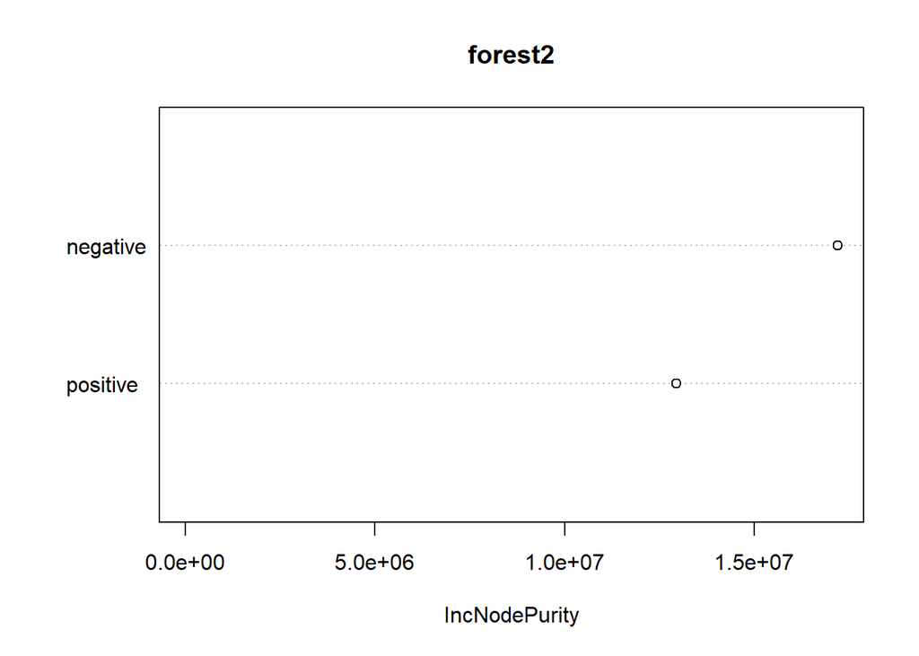

```r
set.seed(100)

forest2 = randomForest(BitcoinPrice~ negative + positive,
            train,
            ntree=1000)

# Finding the importance of variables
varImpPlot(forest2)
```

```r
importance(forest2)
```

```
##          IncNodePurity
## negative      17202738
## positive      12950818
```

```r
#RMSE
pred_forest2 = predict(forest2, newdata=test)
rmse_forest2 = sqrt(mean((pred_forest2-test$BitcoinPrice)^2))
rmse_forest2
```

```
## [1] 2979.694
```

#### Basic Neural Network

```r
set.seed(100)
model2 = nnet(BitcoinPrice~ negative + positive,
             data = train,
             size=5,
             decay=0.1,
             MaxNWts=10000,
             maxit=1000)
#RMSE
pred_neural2 = predict(model2, newdata=test)
rmse_neural2 = sqrt(mean((pred_neural2-test$BitcoinPrice)^2))
rmse_neural2
```

```
## [1] 41170.98
```

### Research Question 2

Does the addition of S&P 500 improve our model?

#### Linear Regression

```r
#Linear regression of emotional sentiments with S&P500
reg3 = lm(BitcoinPrice ~ SP500Price + anger + anticipation + disgust + fear + joy + negative
          + positive + sadness + surprise + trust,
          train)
summary(reg3)
```

```
##
## Call:
## lm(formula = BitcoinPrice ~ SP500Price + anger + anticipation +
##     disgust + fear + joy + negative + positive + sadness + surprise +
##     trust, data = train)
##
## Residuals:
##     Min      1Q  Median      3Q     Max
## -5464.5 -2022.8    37.8  2117.0  4515.8
##
## Coefficients:
##                Estimate Std. Error t value Pr(>|t|)
## (Intercept)  -2.577e+04  1.252e+03 -20.593  < 2e-16 ***
## SP500Price    1.492e+01  2.789e-01  53.486  < 2e-16 ***
## anger         1.699e+02  1.071e+02   1.587  0.11265
## anticipation -1.443e+02  8.786e+01  -1.643  0.10053
## disgust      -7.266e+01  1.313e+02  -0.553  0.58011
## fear          1.675e+01  1.019e+02   0.164  0.86939
## joy           3.080e+02  1.067e+02   2.886  0.00391 **
## negative     -1.196e+02  9.860e+01  -1.213  0.22523
## positive     -2.717e+01  8.872e+01  -0.306  0.75947
## sadness      -1.571e+02  1.107e+02  -1.419  0.15606
## surprise     -1.632e+02  1.073e+02  -1.521  0.12841
## trust        -1.182e+02  8.711e+01  -1.357  0.17476
## ---
## Signif. codes:  0 '***' 0.001 '**' 0.01 '*' 0.05 '.' 0.1 ' ' 1
##
## Residual standard error: 2381 on 4650 degrees of freedom
## Multiple R-squared:  0.3839, Adjusted R-squared:  0.3825
## F-statistic: 263.4 on 11 and 4650 DF,  p-value: < 2.2e-16
```

```r
#RMSE
pred_reg3 = predict(reg3, newdata=test)
rmse_reg3 = sqrt(mean((pred_reg3-test$BitcoinPrice)^2));
rmse_reg3
```

```
## [1] 2348.098
```

```r
#Linear regression of positive/negative sentiments with S&P500
reg4 = lm(BitcoinPrice ~ SP500Price + negative + positive, train)
summary(reg4)
```

```
##
## Call:
## lm(formula = BitcoinPrice ~ SP500Price + negative + positive,
##     data = train)
##
## Residuals:
##     Min      1Q  Median      3Q     Max
## -5352.0 -2009.5    66.9  2127.3  4429.0
##
## Coefficients:
##               Estimate Std. Error t value Pr(>|t|)
## (Intercept) -2.579e+04  1.248e+03 -20.661   <2e-16 ***
## SP500Price   1.491e+01  2.781e-01  53.621   <2e-16 ***
## negative    -1.749e+02  7.175e+01  -2.438   0.0148 *
## positive    -3.061e+01  7.079e+01  -0.432   0.6655
## ---
## Signif. codes:  0 '***' 0.001 '**' 0.01 '*' 0.05 '.' 0.1 ' ' 1
##
## Residual standard error: 2383 on 4658 degrees of freedom
## Multiple R-squared:  0.3819, Adjusted R-squared:  0.3815
## F-statistic: 959.4 on 3 and 4658 DF,  p-value: < 2.2e-16
```

```r
#RMSE
pred_reg4 = predict(reg4, newdata=test)
rmse_reg4 = sqrt(mean((pred_reg4-test$BitcoinPrice)^2));
rmse_reg4
```

```
## [1] 2351.218
```

#### Random Forest

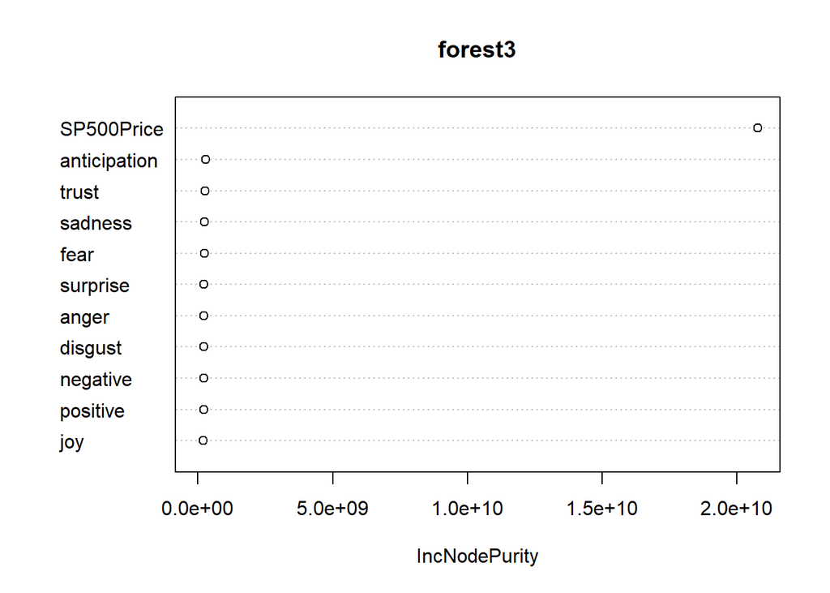

```r
#Random Forest of emotional sentiments with S&P500
set.seed(100)
forest3 = randomForest(BitcoinPrice~ SP500Price + anger + anticipation + disgust
            + fear + joy + negative + positive + sadness + surprise + trust,
            train,
            ntree=1000)

#Finding the importance of variables
varImpPlot(forest3)
```

```r
importance(forest3)
```

```
##              IncNodePurity
## SP500Price     20761667290
## anger            228844290
## anticipation     281305233
## disgust          213278194
## fear             240050342
## joy              196798228
## negative         212935674
## positive         210050028
## sadness          241772948
## surprise         229078928
## trust            262635947
```

```r
pred_forest3 = predict(forest3, newdata=test)
rmse_forest3 = sqrt(mean((pred_forest3-test$BitcoinPrice)^2))
rmse_forest3
```

```
## [1] 2018.227
```

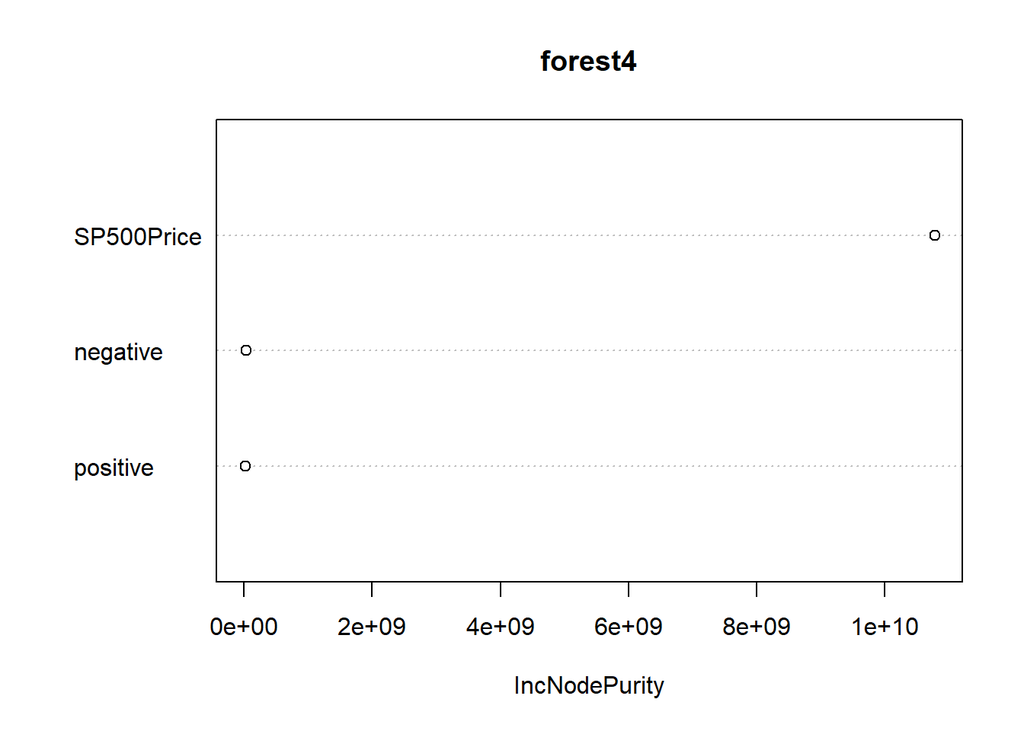

```r
#Random Forest of positive/negative sentiments with S&P500
set.seed(100)
forest4 = randomForest(BitcoinPrice~ SP500Price + negative + positive,
            train,
            ntree=1000)

#Finding the importance of variables
varImpPlot(forest4)
```

```r
importance(forest4)
```

```
##            IncNodePurity
## SP500Price   10783897684
## negative        29460431
## positive        19789316
```

```r
pred_forest4 = predict(forest4, newdata=test)
rmse_forest4 = sqrt(mean((pred_forest4-test$BitcoinPrice)^2))
rmse_forest4
```

```
## [1] 2379.6
```

#### Basic Neural Network

```r
set.seed(100)
model3 = nnet(BitcoinPrice~ SP500Price + anger + anticipation + disgust
            + fear + joy + negative + positive + sadness + surprise + trust,
             data = train,
             size=5,
             decay=0.1,
             MaxNWts=10000,
             maxit=1000)
#RMSE
pred_neural3 = predict(model3, newdata=test)
rmse_neural3 = sqrt(mean((pred_neural3-test$BitcoinPrice)^2))
rmse_neural3
```

```
## [1] 41170.98
```

#### Neural Network Prediction only with S&P500

```r
library(neuralnet)
set.seed(100)
NN = neuralnet(BitcoinPrice~ SP500Price,
             data = train,
            hidden = 10)
plot(NN)

pred_NN = predict(NN, newdata=test)
rmse_NN = sqrt(mean((pred_NN-test$BitcoinPrice)^2))
rmse_NN
```

```
## [1] 2980.492
```

#### Time Series

```r
OLS1 <- lm(bitcoin_price_ts ~ SP500_ts+Bitcoin_Article_ts+Business_ts+Financial_ts+anger_ts+anticipation_ts+disgust_ts+fear_ts+joy_ts+negative_ts+positive_ts+sadness_ts+surprise_ts+trust_ts)

summary(OLS1)
```

```
##
## Call:
## lm(formula = bitcoin_price_ts ~ SP500_ts + Bitcoin_Article_ts +
##     Business_ts + Financial_ts + anger_ts + anticipation_ts +
##     disgust_ts + fear_ts + joy_ts + negative_ts + positive_ts +
##     sadness_ts + surprise_ts + trust_ts)
##
## Residuals:
##    Min     1Q Median     3Q    Max
##  -5311  -1639   -156   1503   4910
##
## Coefficients: (1 not defined because of singularities)
##                      Estimate Std. Error t value Pr(>|t|)
## (Intercept)        -3.556e+04  2.032e+03 -17.498  < 2e-16 ***
## SP500_ts            1.714e+01  4.537e-01  37.781  < 2e-16 ***
## Bitcoin_Article_ts         NA         NA      NA       NA
## Business_ts        -1.128e+03  3.024e+02  -3.730  0.00020 ***
## Financial_ts       -1.019e+03  3.855e+02  -2.643  0.00832 **
## anger_ts            2.296e+02  3.050e+02   0.753  0.45176
## anticipation_ts    -4.312e+02  2.511e+02  -1.717  0.08618 .
## disgust_ts          2.755e+02  4.112e+02   0.670  0.50290
## fear_ts            -6.786e+01  2.931e+02  -0.232  0.81695
## joy_ts              6.852e+02  3.124e+02   2.193  0.02848 *
## negative_ts         1.176e+02  2.924e+02   0.402  0.68764
## positive_ts        -2.349e+02  2.666e+02  -0.881  0.37848
## sadness_ts         -7.953e+02  3.437e+02  -2.314  0.02082 *
## surprise_ts        -3.459e+01  3.068e+02  -0.113  0.91025
## trust_ts           -2.105e+02  2.641e+02  -0.797  0.42551
## ---
## Signif. codes:  0 '***' 0.001 '**' 0.01 '*' 0.05 '.' 0.1 ' ' 1
##
## Residual standard error: 2129 on 1235 degrees of freedom
## Multiple R-squared:  0.5573, Adjusted R-squared:  0.5527
## F-statistic: 119.6 on 13 and 1235 DF,  p-value: < 2.2e-16
```

```r
head(bitcoin_price_ts)
```

```
## 2022-01-01 05:00:00 2022-01-01 06:00:00 2022-01-01 07:00:00 2022-01-01 08:00:00
##            46726.79            47177.32            47029.04            47165.15
## 2022-01-01 09:00:00 2022-01-01 10:00:00
##            47108.44            47081.91
```

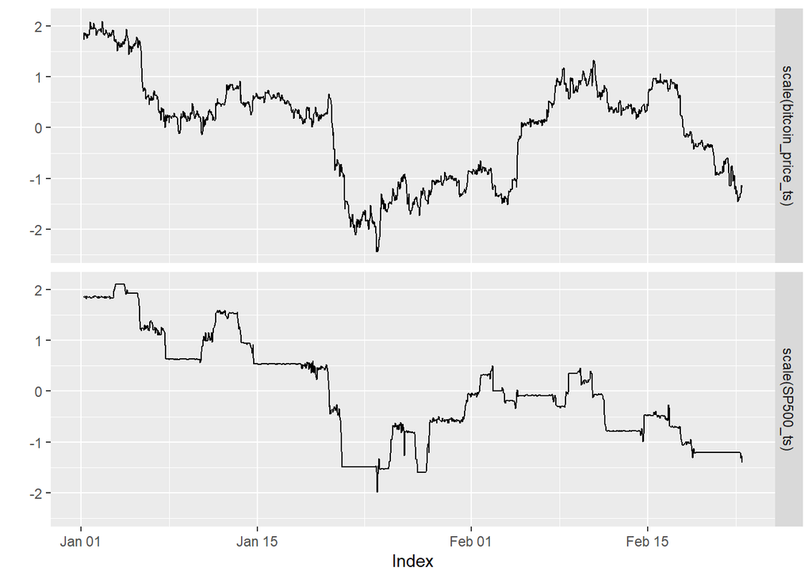

```r
autoplot.zoo(cbind(scale(bitcoin_price_ts),scale(SP500_ts)))
```

##### Finding Lags for Time Series

```r
#Finding the optimal lags
#bitcoinpred.multivariate <- cbind(bitcoin_price_ts, SP500_ts,Bitcoin_Article_ts,Twitter_ts,Business_ts,Financial_ts,anger_ts,anticipation_ts,disgust_ts,fear_ts,joy_ts,negative_ts,positive_ts,sadness_ts,surprise_ts,trust_ts)

bitcoinpred.multivariate <- cbind(bitcoin_price_ts, SP500_ts,Business_ts,Financial_ts,anger_ts,anticipation_ts,disgust_ts,fear_ts,joy_ts,negative_ts,positive_ts,sadness_ts,surprise_ts,trust_ts)

#colnames(bitcoinpred.multivariate) <- cbind("BitcoinPrice", "SP500Price","Bitcoin_Article","Twitter","Business","Financial","anger","anticipation","disgust","fear","joy","negative","positive","sadness","surprise","trust")
colnames(bitcoinpred.multivariate) <- cbind("BitcoinPrice", "SP500Price","Business","Financial","anger","anticipation","disgust","fear","joy","negative","positive","sadness","surprise","trust")

#Divide the data into train and test
train <- head(bitcoinpred.multivariate, round(nrow(bitcoinpred.multivariate) * 0.7))
h <- nrow(bitcoinpred.multivariate) - nrow(train)
test <- tail(bitcoinpred.multivariate, h)

start(test)
```

```
## [1] "2022-02-06 22:00:00 EST"
```

##### Optimize RMSE

```r
#Finding the best RMSE by changing the lag parameter
rmse=0

for (i in 1:50)
{
Modelbitcoinpred <- VAR(train, p=i, type="const", season=NULL, exog=NULL)
summary(Modelbitcoinpred)

#Predicting the values for RMSE
predicted_price <- predict(Modelbitcoinpred, n.ahead=nrow(test))
predicted_Bitcoin_price <- predicted_price$fcst$BitcoinPrice
actual_Bitcoin_price <- test$BitcoinPrice

rmse[i] <- sqrt(mean((actual_Bitcoin_price - predicted_Bitcoin_price[,1])^2))
}

#rmse
```

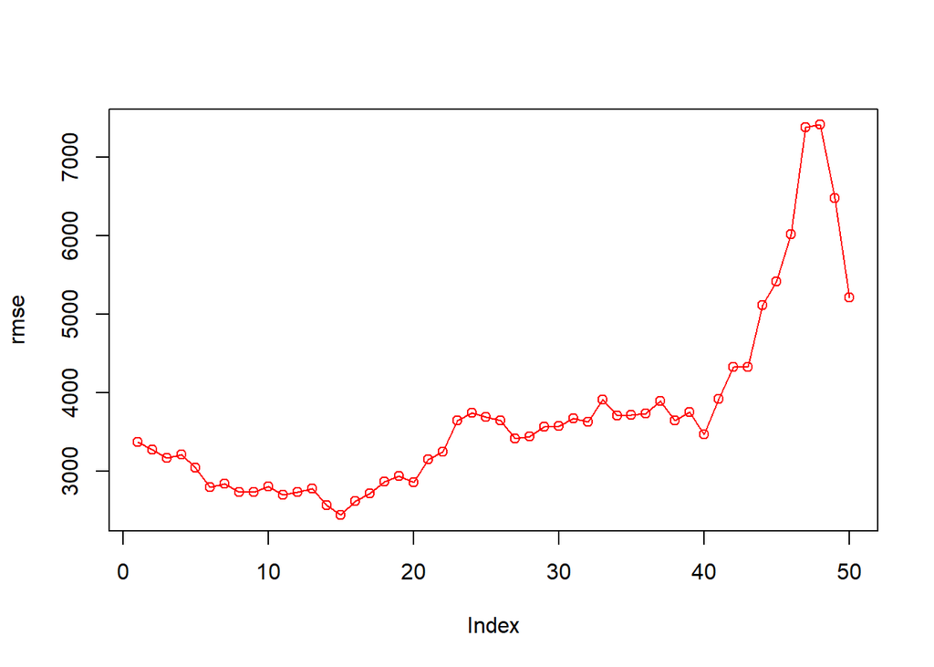

```r
#Ploting RMSE with lag times

plot(rmse, type = "o", col = "red")
```

```r
which(rmse ==  min(rmse))
```

```
## [1] 15
```

```r
#lag of 15 gives the minimum rmse
```

##### Improved Model with 15 Lag Time

```r
#Running the final model with 15 rmse
Modelbitcoinpred <- VAR(train, p=15, type="const", season=NULL, exog=NULL)

#summary(Modelbitcoinpred)
```

```r
#Predicting the values for RMSE
predicted_price <- predict(Modelbitcoinpred, n.ahead=nrow(test))
predicted_Bitcoin_price <- predicted_price$fcst$BitcoinPrice
actual_Bitcoin_price <- test$BitcoinPrice

rmse_time_series <- sqrt(mean((actual_Bitcoin_price - predicted_Bitcoin_price[,1])^2))
rmse_time_series
```

```
## [1] 2444.494
```

### Research Question 3

What is the best predictive model?

#### Comparing RMSE

```r
data.frame(
  models = c(
    'Emotions Linear',
    'Emotions Linear with S&P500',
    'Emotions Basic Neural Network',
    'Positive/Negative Linear',
    'Positive/Negative Linear with S&P500',
    'Positive/Negative Basic Neural Network',
    'Emotions RandomForest',
    'Emotions RandomForest with S&P500',
    'Positive/Negative RandomForest',
    'Positive/Negative RandomForest with S&P500',
    'Positive/Negative with S&P500 Basic Neural Networks',
    'S&P500 Only Basic Neural Networks',
    'Time Series Model'
  ),

   RMSE = c(
    rmse_reg1,
    rmse_reg3,
    rmse_neural1,

    rmse_reg2,
    rmse_reg4,
    rmse_neural2,

    rmse_forest1,
    rmse_forest3,
    rmse_forest2,

    rmse_forest4,
    rmse_neural3,

    rmse_NN,
    rmse_time_series
  )
)
```

```
##                                                 models      RMSE
## 1                                      Emotions Linear  2970.252
## 2                          Emotions Linear with S&P500  2348.098
## 3                        Emotions Basic Neural Network 41170.982
## 4                             Positive/Negative Linear  2979.575
## 5                 Positive/Negative Linear with S&P500  2351.218
## 6               Positive/Negative Basic Neural Network 41170.982
## 7                                Emotions RandomForest  2962.157
## 8                    Emotions RandomForest with S&P500  2018.227
## 9                       Positive/Negative RandomForest  2979.694
## 10          Positive/Negative RandomForest with S&P500  2379.600
## 11 Positive/Negative with S&P500 Basic Neural Networks 41170.982
## 12                   S&P500 Only Basic Neural Networks  2980.492
## 13                                   Time Series Model  2444.494
```